# Bio-Efficacy Dose-Response Report: Chaos_data

Author

Keith Post

Published

January 10, 2026

**⚠️ Modeling Halted**

Based on the biological audit, a non-linear curve was not fit to this data. See the ‘Visual Audit’ below for diagnostics.

## Data Quality & Suitability Audit

### Trial Robustness

- **Signal-to-Noise Ratio (SNR):** In this pipeline, an SNR > 3 is required for reliable parameter estimation; values below this threshold trigger a warning regarding $ED_{50}$ stability. The analysis of this dataset returned an SNR of 21.62, which suggests robust treatment effect with minimal background interference.
- **Dose Coverage:** The chaos_data dataset has a dose ratio of 100. This value indicates exceptional dose distribution across multiple orders of magnitude.

### Data Integrity

- **Structural Integrity:** The dataset passed all automated pre-processing checks, confirming appropriate data types and column mapping for chaos_data.
- **Outlier Count:** No outliers were found in the chaos_data dataset.
- **Plateau Status:** Warning: The biological response did not reach a stable plateau within the tested dose range. Estimations of maximum effect and relative potency ($ED_{50}$) may involve mathematical extrapolation.

### Visual Audit Summary

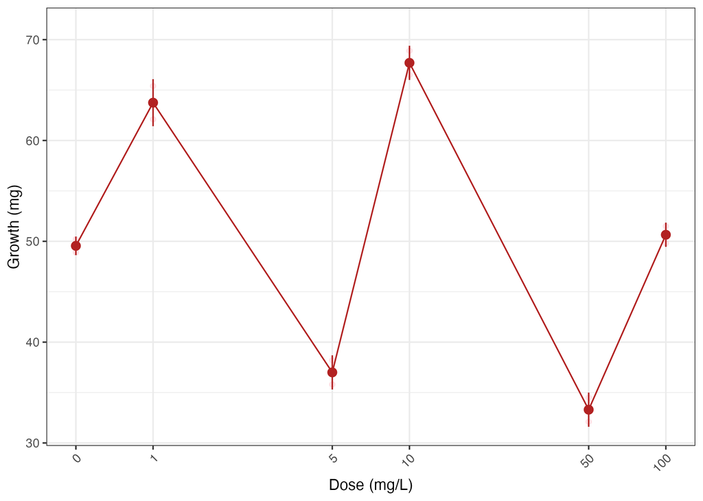

Figure 1: Visual Audit: Distribution of raw replicates across dose levels.